# Long Beach RIPA Analysis: Frequency counts of LB RIPA Data(2019)

Descriptive Analysis 2019

Catalyst California

11/29/2022

# 1) Stop Duration by Response to Calls for Service

Stop Counts and Time Stats by Response to Service Call

| Service Call | Count of Stops | Percent | Average Stop Time(Mins) | Median Stop Time (Mins) | Min Stop Time (Mins) | Max Stop Time (Mins) | Total Time (Mins) |
| --- | --- | --- | --- | --- | --- | --- | --- |
| No | 32,191 | 87.5 | 13.2 | 10 | 1 | 1,440 | 425,478 |
| Yes | 4,597 | 12.5 | 31.7 | 19 | 1 | 1,440 | 145,707 |

*LBPD officers are spending more total time on officer-initiated stops than requests for service. However, on average, LBPD officers are spending more time on service calls than officer-initiated stops.*

## Officer-initiated Stop Counts and Time Stats by Reason

Officer-initiated Stop Counts and Time Stats by Reason

| Reason | Count of Stops | Percent | Average Stop Time(Mins) | Median Stop Time (Mins) | Min Stop Time (Mins) | Max Stop Time (Mins) | Total Time (Mins) |
| --- | --- | --- | --- | --- | --- | --- | --- |
| Traffic Violation | 24,687 | 76.7 | 10.5 | 7.0 | 1 | 1,352 | 259,055 |
| Reasonable Suspicion | 6,290 | 19.5 | 20.6 | 12.0 | 1 | 1,440 | 129,607 |
| Known to be on Parole / Probation / PRCS / Mandatory Supervision | 538 | 1.7 | 25.6 | 15.0 | 1 | 1,430 | 13,763 |
| Investigation to determine whether the person was truant | 310 | 1.0 | 25.7 | 19.5 | 1 | 190 | 7,969 |
| Knowledge of outstanding arrest warrant/wanted person | 249 | 0.8 | 44.1 | 21.0 | 1 | 740 | 10,981 |
| Consensual Encounter resulting in a search | 116 | 0.4 | 34.3 | 20.0 | 2 | 210 | 3,983 |
| Possible conduct warranting discipline under Education Code sections 48900, 48900.2, 48900.3, 48900.4 and 48900.7 | 1 | 0.0 | 120.0 | 120.0 | 120 | 120 | 120 |

*The top 2 reasons for officer-initiated stops are traffic violation and reasonable suspicion.*

# 2) Calls for Service by Race

Calls for Service by Race

| Service Call | Race | Count of Stops | Percent |
| --- | --- | --- | --- |
| No | Asian | 1,803 | 91.57 |
| Yes | Asian | 166 | 8.43 |
| No | Black/African American | 9,444 | 84.97 |
| Yes | Black/African American | 1,670 | 15.03 |
| No | Hispanic/Latino/a | 12,967 | 88.04 |
| Yes | Hispanic/Latino/a | 1,761 | 11.96 |
| No | Middle Eastern or South Asian | 524 | 93.91 |
| Yes | Middle Eastern or South Asian | 34 | 6.09 |
| No | Native American | 37 | 92.50 |
| Yes | Native American | 3 | 7.50 |
| No | Pacific Islander | 362 | 88.94 |
| Yes | Pacific Islander | 45 | 11.06 |
| No | Two or More Races | 2,128 | 93.09 |
| Yes | Two or More Races | 158 | 6.91 |
| No | White | 7,930 | 84.17 |
| Yes | White | 1,491 | 15.83 |

# 3) Number of Unique Stops (stop id) for Officer-initiated Stops

```
FALSE [1] 32191
```

*There are 32,191 unique officer-initiated stops.*

# 4) Number of People Stopped by Officers for Officer-initiated Stops

```
FALSE [1] 35195
```

*35,195 total number of people were stopped by LBPD in 2019 for officer-initiated reasons.*

# 5) Perceived Age Stats for Officer-initiated Stops

| Average Age | Median Age | Min Age | Max Age |
| --- | --- | --- | --- |
| 34.93414 | 30 | 1 | 120 |

*The average age of a civilian stopped by LBPD for officer-initiated reasons is ~34-35 years. The median age is 30 years. The age of a civilian stopped by LBPD ranges from 1-120 years.*

# 6) Perceived Races for Officer-initiated Stops

Stop Counts by Race

| Race | count | Percent |
| --- | --- | --- |
| Hispanic/Latino/a | 12,967 | 36.8 |
| Black/African American | 9,444 | 26.8 |
| White | 7,930 | 22.5 |
| Two or More Races | 2,128 | 6.0 |
| Asian | 1,803 | 5.1 |
| Middle Eastern or South Asian | 524 | 1.5 |
| Pacific Islander | 362 | 1.0 |
| Native American | 37 | 0.1 |

*Hispanic/Latinx and Black Californians make up the vast majority of people stopped by LBPD for officer-initiated stops.*

# 7) Actions Taken for Officer-initiated Stops

Top 100 Actions Taken

| Actions Taken | count | Percent |
| --- | --- | --- |
| None | 25,511 | 72.48 |
| Curbside detention | 1,983 | 5.63 |
| Curbside detention,Search of person was conducted | 1,103 | 3.13 |
| Handcuffed or flex cuffed,Search of person was conducted | 499 | 1.42 |
| Asked for consent to search person,Curbside detention | 440 | 1.25 |
| Patrol car detention | 437 | 1.24 |
| Patrol car detention,Search of person was conducted | 320 | 0.91 |
| Handcuffed or flex cuffed,Patrol car detention,Search of person was conducted | 248 | 0.70 |
| Curbside detention,Search of person was conducted,Search of property was conducted | 233 | 0.66 |
| Person removed from vehicle by order,Search of person was conducted | 207 | 0.59 |
| Curbside detention,Person removed from vehicle by order,Search of person was conducted | 185 | 0.53 |
| Person removed from vehicle by order | 170 | 0.48 |
| Asked for consent to search person,Patrol car detention | 141 | 0.40 |
| Asked for consent to search person,Curbside detention,Search of person was conducted | 140 | 0.40 |
| Curbside detention,Handcuffed or flex cuffed,Search of person was conducted | 135 | 0.38 |
| Asked for consent to search person,Person removed from vehicle by order | 98 | 0.28 |
| Handcuffed or flex cuffed | 94 | 0.27 |
| Curbside detention,Person removed from vehicle by order,Search of person was conducted,Search of property was conducted | 90 | 0.26 |
| Curbside detention,Person removed from vehicle by order | 78 | 0.22 |
| Curbside detention,Handcuffed or flex cuffed,Search of person was conducted,Search of property was conducted | 73 | 0.21 |
| Asked for consent to search person,Curbside detention,Person removed from vehicle by order | 70 | 0.20 |
| Curbside detention,Property was seized,Search of person was conducted | 64 | 0.18 |
| Curbside detention,Handcuffed or flex cuffed,Patrol car detention,Search of person was conducted | 60 | 0.17 |
| Search of person was conducted | 53 | 0.15 |
| Handcuffed or flex cuffed,Search of property was conducted | 48 | 0.14 |
| Patrol car detention,Person removed from vehicle by order,Search of person was conducted | 48 | 0.14 |
| Physical or Vehicle contact | 44 | 0.13 |
| Asked for consent to search person,Asked for consent to search property,Curbside detention,Person removed from vehicle by order,Search of person was conducted,Search of property was conducted | 42 | 0.12 |
| Asked for consent to search person,Asked for consent to search property,Curbside detention,Search of person was conducted,Search of property was conducted | 42 | 0.12 |
| Asked for consent to search person,Handcuffed or flex cuffed | 41 | 0.12 |

[output cut: 70 more lines]

*There are 679 unique observations for actions taken from officer-initiated stops. 72.5% of the observations result in no action taken while 27.5% of observations result in some action, usually curbside detention combined with another action taken.*

# 8) Reasons for Officer-initiated Stops by Race

Reason For Stop Frequency by Race

| Reasons for Stop | Race | count | Percent |
| --- | --- | --- | --- |
| Traffic Violation | Asian | 1,583 | 87.80 |
| Reasonable Suspicion | Asian | 175 | 9.71 |
| Known to be on Parole / Probation / PRCS / Mandatory Supervision | Asian | 15 | 0.83 |
| Investigation to determine whether the person was truant | Asian | 14 | 0.78 |
| Knowledge of outstanding arrest warrant/wanted person | Asian | 12 | 0.67 |
| Consensual Encounter resulting in a search | Asian | 4 | 0.22 |
| Traffic Violation | Black/African American | 6,353 | 67.27 |
| Reasonable Suspicion | Black/African American | 2,618 | 27.72 |
| Known to be on Parole / Probation / PRCS / Mandatory Supervision | Black/African American | 208 | 2.20 |
| Investigation to determine whether the person was truant | Black/African American | 131 | 1.39 |
| Knowledge of outstanding arrest warrant/wanted person | Black/African American | 99 | 1.05 |
| Consensual Encounter resulting in a search | Black/African American | 35 | 0.37 |
| Traffic Violation | Hispanic/Latino/a | 9,763 | 75.29 |
| Reasonable Suspicion | Hispanic/Latino/a | 2,583 | 19.92 |
| Known to be on Parole / Probation / PRCS / Mandatory Supervision | Hispanic/Latino/a | 267 | 2.06 |
| Investigation to determine whether the person was truant | Hispanic/Latino/a | 172 | 1.33 |
| Knowledge of outstanding arrest warrant/wanted person | Hispanic/Latino/a | 125 | 0.96 |
| Consensual Encounter resulting in a search | Hispanic/Latino/a | 56 | 0.43 |
| Possible conduct warranting discipline under Education Code sections 48900, 48900.2, 48900.3, 48900.4 and 48900.7 | Hispanic/Latino/a | 1 | 0.01 |
| Traffic Violation | Middle Eastern or South Asian | 473 | 90.27 |
| Reasonable Suspicion | Middle Eastern or South Asian | 43 | 8.21 |
| Known to be on Parole / Probation / PRCS / Mandatory Supervision | Middle Eastern or South Asian | 4 | 0.76 |
| Knowledge of outstanding arrest warrant/wanted person | Middle Eastern or South Asian | 2 | 0.38 |
| Consensual Encounter resulting in a search | Middle Eastern or South Asian | 1 | 0.19 |
| Investigation to determine whether the person was truant | Middle Eastern or South Asian | 1 | 0.19 |
| Traffic Violation | Native American | 25 | 67.57 |
| Reasonable Suspicion | Native American | 11 | 29.73 |
| Known to be on Parole / Probation / PRCS / Mandatory Supervision | Native American | 1 | 2.70 |
| Traffic Violation | Pacific Islander | 247 | 68.23 |
| Reasonable Suspicion | Pacific Islander | 95 | 26.24 |
| Investigation to determine whether the person was truant | Pacific Islander | 7 | 1.93 |
| Known to be on Parole / Probation / PRCS / Mandatory Supervision | Pacific Islander | 7 | 1.93 |
| Knowledge of outstanding arrest warrant/wanted person | Pacific Islander | 4 | 1.10 |
| Consensual Encounter resulting in a search | Pacific Islander | 2 | 0.55 |
| Traffic Violation | Two or More Races | 1,783 | 83.79 |
| Reasonable Suspicion | Two or More Races | 284 | 13.35 |
| Known to be on Parole / Probation / PRCS / Mandatory Supervision | Two or More Races | 36 | 1.69 |
| Investigation to determine whether the person was truant | Two or More Races | 12 | 0.56 |
| Consensual Encounter resulting in a search | Two or More Races | 7 | 0.33 |
| Knowledge of outstanding arrest warrant/wanted person | Two or More Races | 6 | 0.28 |
| Traffic Violation | White | 5,757 | 72.60 |
| Reasonable Suspicion | White | 1,861 | 23.47 |
| Known to be on Parole / Probation / PRCS / Mandatory Supervision | White | 144 | 1.82 |
| Investigation to determine whether the person was truant | White | 73 | 0.92 |
| Knowledge of outstanding arrest warrant/wanted person | White | 62 | 0.78 |
| Consensual Encounter resulting in a search | White | 33 | 0.42 |

*The vast majority of reason the LBPD stopped a civilian was due to traffic violation(73.83%), with the second most common reason being Reasonable Suspicion(21.7%).*

# 9) Results of Officer-initiated Stops

Result For Stop Frequency

| Result of Stop | count | Percent |
| --- | --- | --- |
| Citation for infraction | 15,386 | 43.72 |
| Warning (verbal or written) | 7,049 | 20.03 |
| No Action | 6,689 | 19.01 |
| Field interview card completed | 1,651 | 4.69 |
| Multiple Results | 1,464 | 4.16 |
| In-field cite and release | 1,081 | 3.07 |
| Custodial Arrest without warrant | 1,027 | 2.92 |
| Custodial Arrest pursuant to outstanding warrant | 635 | 1.80 |
| Psychiatric hold | 146 | 0.41 |
| Noncriminal transport or caretaking transport | 45 | 0.13 |
| Contacted parent/legal guardian or other person responsible for the minor | 20 | 0.06 |
| Contacted U.S. Department of Homeland Security | 1 | 0.00 |
| Referral to school counselor or other support staff | 1 | 0.00 |

*The vast majority of officer-initiated stops result in a citation for infraction, followed by a verbal/written warning by an LBPD officer and no action.*

## No Action by Race

No Action Result by Race

| Race | count | Percent |
| --- | --- | --- |
| Hispanic/Latino/a | 2,541 | 37.99 |
| Black/African American | 2,046 | 30.59 |
| White | 1,381 | 20.65 |
| Two or More Races | 329 | 4.92 |
| Asian | 264 | 3.95 |
| Pacific Islander | 66 | 0.99 |
| Middle Eastern or South Asian | 56 | 0.84 |
| Native American | 6 | 0.09 |

# 10) Time of Day/Month

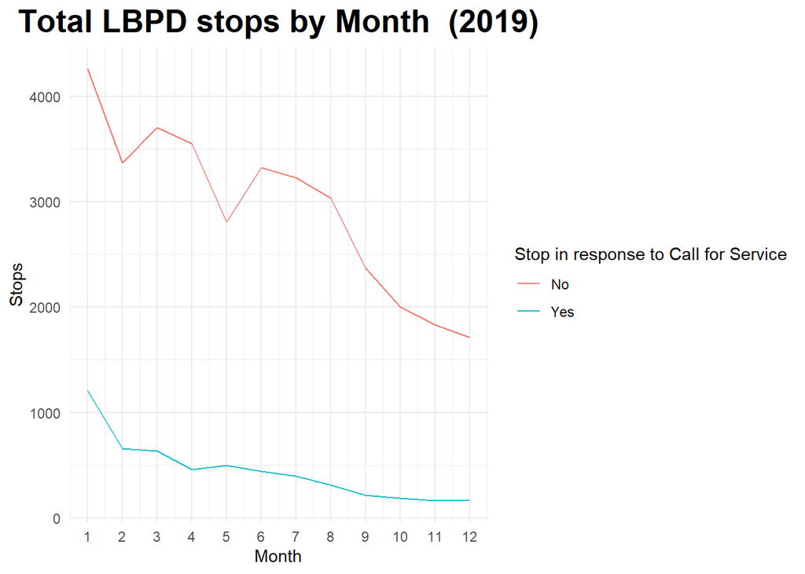

*The number of LBPD officer-initiated and calls for service stops in 2019 peaked in January and slowly decreased overtime.*

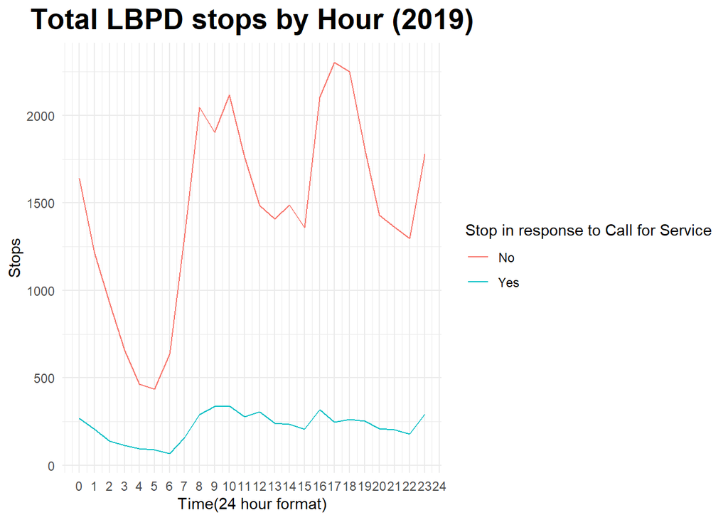

*The vast majority of stops occur between the hours of 5:00-6:00 P.M, followed by 10:00 a.m, 4:00 P.M., and 8:00 A.M. The least amount of stops occur between the hours of 1:00 A.M.-5:00 A.M.*

# 11) Contraband/Hit Rates

Contraband Found out of Total Searches by Race

| Race | Contraband Found | count | Percent |
| --- | --- | --- | --- |
| Asian | no | 121 | 76.58 |
| Asian | yes | 37 | 23.42 |
| Black/African American | no | 1,520 | 83.70 |
| Black/African American | yes | 296 | 16.30 |
| Hispanic/Latino/a | no | 1,776 | 81.02 |
| Hispanic/Latino/a | yes | 416 | 18.98 |
| Middle Eastern or South Asian | no | 20 | 100.00 |
| Native American | no | 3 | 60.00 |
| Native American | yes | 2 | 40.00 |
| Pacific Islander | no | 51 | 77.27 |
| Pacific Islander | yes | 15 | 22.73 |
| Two or More Races | no | 212 | 80.61 |
| Two or More Races | yes | 51 | 19.39 |
| White | no | 785 | 80.76 |
| White | yes | 187 | 19.24 |